# NOOA Storm Data Analysis - Which Events Hurt Most

## Synopsis

This analysis explores the Storm data of NOOA and tries to identify the most harmful types of events across the United States (1) with respect to population health and (2) with the greatest economic consequences. As the results, it is found that Tornado brings most damage to population health, followed by Excessive Heat, Flood, and Lighting, while Flood causes most important economic consequences followed by Hurricane/Typhoon and Storm Surge.

## Data Processing

```r
library(knitr)
library(dplyr)
library(lubridate)
library(ggplot2)
```

From the [course website](https://d396qusza40orc.cloudfront.net/repdata%2Fdata%2FStormData.csv.bz2) I downloaded the data file in bz2 format and saved it into the subfolder **data** of my working folder.

1. Read in the data and examine the structure

```r
dfStorm <- read.csv("./data/repdata-data-StormData.csv.bz2",
                   stringsAsFactors = F)
```

Check the dimensions of this dataset

```r
dim(dfStorm)
```

[1] 902297 37

Check the variables contained

```r
names(dfStorm)
```

[1] “STATE__" “BGN_DATE” “BGN_TIME” “TIME_ZONE” “COUNTY”  
[6] “COUNTYNAME” “STATE” “EVTYPE” “BGN_RANGE” “BGN_AZI”  
[11] “BGN_LOCATI” “END_DATE” “END_TIME” “COUNTY_END” “COUNTYENDN” [16] “END_RANGE” “END_AZI” “END_LOCATI” “LENGTH” “WIDTH”  
[21] “F” “MAG” “FATALITIES” “INJURIES” “PROPDMG”  
[26] “PROPDMGEXP” “CROPDMG” “CROPDMGEXP” “WFO” “STATEOFFIC” [31] “ZONENAMES” “LATITUDE” “LONGITUDE” “LATITUDE_E” “LONGITUDE_” [36] “REMARKS” “REFNUM”

2. According to the questions targeted, keep only the fields most relevant to this analyis, i.e.
- `BGN_DATE`, the date when the event began
- `EVTYPE`, the type of natural event
- `FATALITIES`, the number of lives lost caused by the event
- `INJURIES`, the number of injuries caused by the event
- `PROPDMG`, the dollar amount of property damage
- `PROPDMGEXP`, the exponential symbol for property damage dollar amount
- `CROPDMG`, the dollar amount of crop damage
- `CROPDMGEXP`, the exponential symbol for crop damage dollar amount

```r
dfStorm <- dfStorm %>%
    tbl_df() %>% # tbl data frame format which works better with dplyr
    select(BGN_DATE, EVTYPE,
           FATALITIES, INJURIES,
           PROPDMG, PROPDMGEXP,
           CROPDMG, CROPDMGEXP)
```

```r
dfStorm$BGN_DATE <- mdy_hms(dfStorm$BGN_DATE)
dfStorm$YEAR <-as.integer(year(dfStorm$BGN_DATE))
```

- Examine the number of records per year with a plot

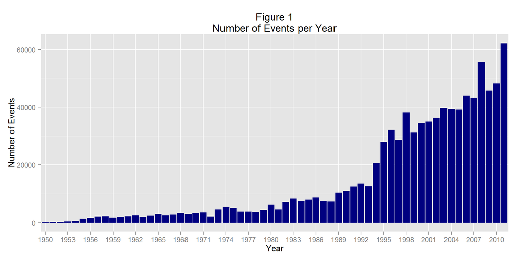

```r
ggplot(dfStorm,
       aes(x = factor(YEAR))) +
    geom_bar(fill = "navyblue") +
    labs(x = "Year",
         y = "Number of Events",
         title = "Figure 1\nNumber of Events per Year") +
    scale_x_discrete(breaks=seq(from = min(dfStorm$YEAR),
                                to = max(dfStorm$YEAR),
                                by = 3))
```

The plot indicates that earlier years have limited events recorded while later years have more complete records. 20,000 events per year can be set as a cutoff point.

- Choose the years whose nubmer of recorded events is above 20,000 per year

```r
okYear <- dfStorm %>%
    group_by(YEAR) %>% # by year
    summarize(N = n()) %>% # count events
    filter(N>20000) %>% # set threshold as 20000
    select(YEAR) %>% # get the year column
    unlist() # convert into a vector

dfStorm <- dfStorm[dfStorm$YEAR %in% okYear, ] # subset the data by years
```

4. Align crop and property damages dollar amounts into USD millions based on symbols in `PROPDMGEXP` or `CROPDMGEXP` fields, i.e.
- ‘K’ meaning thousands, hence to be divided by 1000
- ‘M’ meaning millions, hence no change
- ‘B’ meaning billions, hence to be multiplied by 1000
- other symbols considered to be unclean data hence zero

```r
mPROP <- as.vector(sapply(dfStorm$PROPDMGEXP,
                          switch,
                          K = 0.001,
                          M = 1,
                          B = 1000,
                          0)) # this is the value for other symbols
mCROP <- as.vector(sapply(dfStorm$CROPDMGEXP,
                          switch,
                          K = 0.001,
                          M = 1,
                          B = 1000,
                          0))

dfStorm$PROPDMG <- dfStorm$PROPDMG * mPROP
dfStorm$CROPDMG <- dfStorm$CROPDMG * mCROP
```

## Results

To simplify the measure for human population health, I make an assumption that an injury is equavalent to half a fatality. Hence the new proxy measure `HealthImpact = Fatality + 0.5 * Injury` is introduced and calculated

```r
dfHealth <- dfStorm %>%
    group_by(EVTYPE) %>%
    summarize(Fatality = sum(FATALITIES),
              Injury = sum(INJURIES),
              HealthImpact = Fatality + 0.5 * Injury) %>%
    filter(HealthImpact > 0) %>%
    arrange(desc(HealthImpact))
```

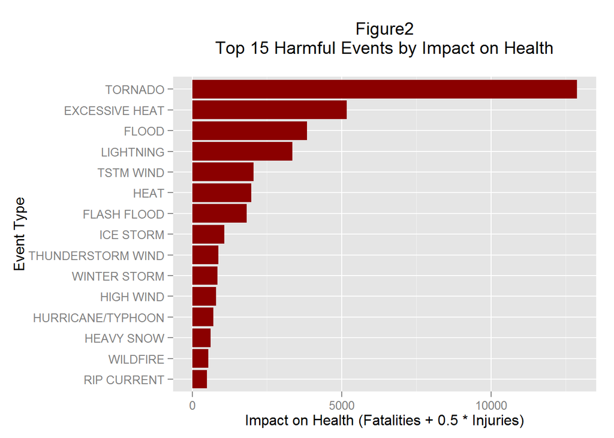

```r
ggplot(dfHealth[1:15,],
       aes(x = reorder(EVTYPE,
                      HealthImpact),
           y = HealthImpact)) +
    geom_bar(stat = "identity", fill = "Darkred") +
    coord_flip() +
    labs (x = "Event Type",
          y = "Impact on Health (Fatalities + 0.5 * Injuries)",
          title = "Figure2\nTop 15 Harmful Events by Impact on Health\n")
```

**It shows that the most harmful event in terms of wrecking damage to population health is Tornado. Following that are Excessive heat, Flood and Lightning.**

```r
dfEconomy <- dfStorm %>%
    group_by(EVTYPE) %>%
    summarize(Crop = sum(CROPDMG),
              Property = sum(PROPDMG),
              Total = Crop + Property) %>%
    filter(Total > 0) %>%
    arrange(desc(Total), desc(Crop))
```

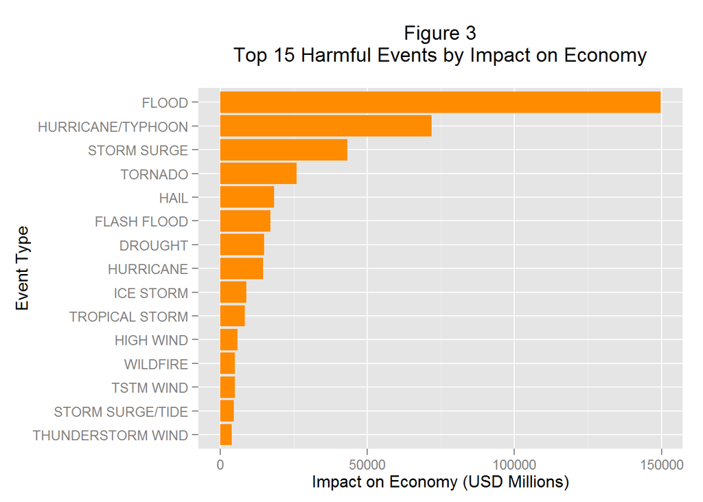

```r
ggplot(dfEconomy[1:15,],
       aes(x = reorder(EVTYPE,
                      Total),
           y = Total)) +
    geom_bar(stat = "identity", fill = "Darkorange") +
    coord_flip() +
    labs (x = "Event Type",
          y = "Impact on Economy (USD Millions)",
          title = "Figure 3\nTop 15 Harmful Events by Impact on Economy\n")
```

**It shows that the most harmful event in terms of wrecking damage to crops and properties is Flood. Following that are Hurricane/Typhoon and Storm Surge.**